# Classifier - Capstone Project

### Classifiers for bidders data

The aim of this notebook is to use two optimize and use classifiers for the data in "bidders_full_features.csv" file. The classifiers will be a Random Forest and an XGBooster. The optimization method will be by a random search in the parameter space, and the best model will be selected. After selection the model will be evaluated with a 10 fold cross-validated AUROC curve result.

```python
# Import the necessary libraries
import numpy as np
import pandas as pd
from time import time
import matplotlib.pyplot as plt
from IPython.display import display # Allows the use of display() for DataFrames

np.set_printoptions(threshold=100)
pd.set_option('display.max_rows', 100,
              'display.max_columns', 120,
              'display.height', 10)

random_state=0

# Pretty display for notebooks
%matplotlib inline

# Load the bidders train dataset
X = pd.read_csv("data/bidders_full_features.csv", index_col=0)

# get the column names of the variables
X_columns = list(X.columns.values[1:-1])

# Shuffle the data frame to account for any possible biases when making the bids dataset
X = X.sample(frac=1, random_state=random_state)

# Separate the outcomes to a series
y = X.outcome

# Drop the outcome column from the dataset
X.drop(columns=['bidder_id', 'outcome'], inplace=True)

# Display the first records the features dataset case
print("The first few lines of the bidders dataset are as follows:")
display(X.head(n=3))
print("\n")

# Display the first records the labels dataset case
print("The first few lines of the bidders dataset are as follows:")
display(y.head(n=3))

# turn into nd arrays
X = X.values
y = y.values
```

```
The first few lines of the bidders dataset are as follows:
```

|  | num_bids | simultaneous_bid_ratio | earliest_bid | latest_bid | middle_bid | mean_bid_timestamp | std_bid_timestamp | num_periods_participated_in | smallest_interval | largest_interval | median_intervals | mean_intervals | std_intervals | counts_n_country | counts_n_small_country | max_count_country | min_count_country | mean_count_country | median_count_country | std_count_country | counts_n_device | max_count_device | min_count_device | mean_count_device | median_count_device | std_count_device | counts_n_auction | max_count_auction | min_count_auction | … |
| --- | --- | --- | --- | --- | --- | --- | --- | --- | --- | --- | --- | --- | --- | --- | --- | --- | --- | --- | --- | --- | --- | --- | --- | --- | --- | --- | --- | --- | --- | --- |
| 1408 | 0.000002 | 0.0 | 0.920967 | 0.983391 | 0.935304 | 0.943725 | 0.106714 | 0.0 | 0.000482 | 0.359869 | 0.436629 | 0.302562 | 0.352946 | 0.000000 | 0.0 | 0.000018 | 0.000755 | 0.000577 | 0.000755 | 0.000000 | 0.000382 | 0.000030 | 0.0 | 0.000252 | 0.000252 | 0.000590 | 0.000617 | 0.000032 | 0.0 | … |
| 1018 | 0.000144 | 0.0 | 0.905121 | 0.999453 | 0.945294 | 0.947020 | 0.109946 | 0.0 | 0.000076 | 0.071766 | 0.012417 | 0.017848 | 0.032173 | 0.044944 | 0.0 | 0.000292 | 0.000000 | 0.001453 | 0.000503 | 0.000735 | 0.017959 | 0.000118 | 0.0 | 0.000152 | 0.000000 | 0.000720 | 0.014180 | 0.000736 | 0.0 | … |
| 651 | 0.000122 | 0.0 | 0.025103 | 0.545342 | 0.497597 | 0.469803 | 0.457147 | 1.0 | 0.000005 | 0.135860 | 0.012066 | 0.023873 | 0.058463 | 0.044944 | 0.0 | 0.000298 | 0.000000 | 0.001218 | 0.000000 | 0.000769 | 0.012228 | 0.000133 | 0.0 | 0.000252 | 0.000000 | 0.001077 | 0.019112 | 0.000144 | 0.0 | … |

```
The first few lines of the bidders dataset are as follows:
```

```
1408    0.0
1018    0.0
651     0.0
Name: outcome, dtype: float64
```

#### Random Search for the optimal parameter space on Random Forest

The next step after loading the data is performing the GridSearch. We will use a cross validated random search for the job. The default way of splitting is stratified which is good for our highly skewed dataset, and the scoring method is AUROC curve.

```python
from scipy.stats import randint as sp_randint

from sklearn.model_selection import RandomizedSearchCV
from sklearn.ensemble import RandomForestClassifier
from sklearn.metrics import roc_auc_score, make_scorer


# initialize the classifier
clf_RF = RandomForestClassifier(n_estimators=2000, n_jobs=-1, random_state=random_state)

# find the number of features for parameter optimization
num_features = X.shape[1]

# make scorer
auc_scorer = make_scorer(roc_auc_score, needs_threshold=True)#, needs_proba=True

# params
m_depths = [None] + list(range(2, 21, 3))

# specify parameters and distributions to sample from
param_dist_rf = {"max_depth": m_depths, # [None, 2, 5, 8, 11, 14, 17, 20]
                 "max_features": sp_randint(1, num_features),
                 "min_samples_split": sp_randint(2, 100),
                 "min_samples_leaf": sp_randint(1, 100),
                 "bootstrap": [True, False],
                 "criterion": ["gini", "entropy"]}

n_iter_search = 30 # was 20

# run randomized search
random_search_RF = RandomizedSearchCV(clf_RF,
                                      param_distributions=param_dist_rf,
                                      n_iter=n_iter_search,
                                      scoring=auc_scorer,
                                      random_state=random_state,
                                      n_jobs=-1,
                                      return_train_score=True)

start = time()
random_search_RF.fit(X, y)
print("RandomizedSearchCV took {:.2f} seconds for {} candidates"
      " parameter settings.\n".format((time() - start), n_iter_search))

# display the dataframe without the parameters column for better rendering
display(pd.DataFrame(random_search_RF.cv_results_).drop('params', axis=1))

best_parameters_RF = pd.Series(random_search_RF.best_params_)

# display the best set of parameters
display(best_parameters_RF)
```

```
RandomizedSearchCV took 1085.90 seconds for 30 candidates parameter settings.
```

|  | mean_fit_time | mean_score_time | mean_test_score | mean_train_score | param_bootstrap | param_criterion | param_max_depth | param_max_features | param_min_samples_leaf | param_min_samples_split | rank_test_score | split0_test_score | split0_train_score | split1_test_score | split1_train_score | split2_test_score | split2_train_score | std_fit_time | std_score_time | std_test_score | std_train_score |
| --- | --- | --- | --- | --- | --- | --- | --- | --- | --- | --- | --- | --- | --- | --- | --- | --- | --- | --- | --- | --- | --- |
| 0 | 31.299054 | 1.578122 | 0.913426 | 0.948066 | True | entropy | 14 | 65 | 68 | 69 | 5 | 0.943624 | 0.941336 | 0.938255 | 0.946467 | 0.858233 | 0.956394 | 0.627911 | 0.297621 | 0.039032 | 0.006250 |
| 1 | 24.731737 | 0.975966 | 0.914272 | 0.973842 | False | entropy | 8 | 22 | 37 | 89 | 3 | 0.941098 | 0.972073 | 0.936421 | 0.971396 | 0.865149 | 0.978055 | 5.445544 | 0.231723 | 0.034737 | 0.002992 |
| 2 | 11.058934 | 1.718888 | 0.904323 | 0.939021 | True | gini | None | 13 | 59 | 67 | 15 | 0.931439 | 0.932825 | 0.933637 | 0.935237 | 0.847730 | 0.949000 | 0.379481 | 0.513090 | 0.039969 | 0.007125 |
| 3 | 21.463069 | 1.785810 | 0.909350 | 0.940749 | True | entropy | 20 | 47 | 89 | 83 | 9 | 0.941098 | 0.933837 | 0.940343 | 0.938991 | 0.846425 | 0.949419 | 2.014089 | 0.135370 | 0.044431 | 0.006482 |
| 4 | 108.691352 | 2.373687 | 0.900751 | 0.998475 | False | entropy | 14 | 73 | 10 | 22 | 20 | 0.927083 | 0.998153 | 0.910356 | 0.998203 | 0.864692 | 0.999068 | 5.888914 | 0.386536 | 0.026361 | 0.000420 |
| 5 | 50.975613 | 2.840120 | 0.890585 | 0.939596 | False | gini | 8 | 70 | 80 | 49 | 28 | 0.917235 | 0.936984 | 0.907794 | 0.937852 | 0.846588 | 0.943952 | 7.819304 | 0.160802 | 0.031303 | 0.003100 |
| 6 | 38.846525 | 2.030775 | 0.899054 | 0.944779 | True | gini | 8 | 89 | 50 | 31 | 25 | 0.919003 | 0.938285 | 0.918960 | 0.944542 | 0.859081 | 0.951512 | 3.698589 | 0.286453 | 0.028223 | 0.005403 |
| 7 | 54.000747 | 1.969333 | 0.907719 | 0.979588 | False | entropy | 17 | 40 | 33 | 67 | 11 | 0.938384 | 0.979075 | 0.930031 | 0.976658 | 0.854580 | 0.983032 | 2.556006 | 0.489242 | 0.037675 | 0.002627 |
| 8 | 43.782579 | 1.908618 | 0.910726 | 0.978578 | False | entropy | 20 | 33 | 32 | 76 | 8 | 0.937437 | 0.978031 | 0.932055 | 0.975888 | 0.862539 | 0.981815 | 3.451224 | 0.725300 | 0.034094 | 0.002450 |
| 9 | 40.041394 | 1.262490 | 0.915531 | 0.954751 | True | entropy | 8 | 76 | 56 | 30 | 1 | 0.945960 | 0.949783 | 0.935978 | 0.952418 | 0.864496 | 0.962050 | 5.790769 | 0.107766 | 0.036264 | 0.005272 |
| 10 | 21.170962 | 1.593381 | 0.903717 | 0.943723 | True | gini | None | 37 | 54 | 7 | 18 | 0.929230 | 0.937980 | 0.929019 | 0.942119 | 0.852753 | 0.951070 | 0.621611 | 0.601344 | 0.035984 | 0.005463 |
| 11 | 12.089579 | 1.021151 | 0.899767 | 0.928816 | True | gini | 11 | 18 | 80 | 6 | 23 | 0.927399 | 0.923141 | 0.933068 | 0.923959 | 0.838661 | 0.939347 | 0.608743 | 0.273075 | 0.043207 | 0.007454 |
| 12 | 38.651913 | 1.813642 | 0.908490 | 0.978820 | False | gini | 5 | 32 | 2 | 67 | 10 | 0.926073 | 0.972410 | 0.925729 | 0.978616 | 0.873565 | 0.985433 | 2.286917 | 0.604265 | 0.024660 | 0.005318 |
| 13 | 40.844124 | 1.811510 | 0.906536 | 0.950473 | False | entropy | 2 | 36 | 12 | 48 | 12 | 0.934596 | 0.947808 | 0.938382 | 0.942873 | 0.846457 | 0.960739 | 0.346797 | 0.541380 | 0.042448 | 0.007533 |
| 14 | 21.250117 | 2.035779 | 0.912825 | 0.950259 | True | entropy | None | 15 | 54 | 14 | 7 | 0.940152 | 0.943745 | 0.938825 | 0.946563 | 0.859342 | 0.960470 | 2.822050 | 0.708065 | 0.037767 | 0.007311 |
| 15 | 57.398166 | 1.192972 | 0.885159 | 0.941644 | False | gini | 11 | 76 | 69 | 8 | 30 | 0.904735 | 0.939883 | 0.901468 | 0.938333 | 0.849165 | 0.946717 | 3.299655 | 0.275471 | 0.025449 | 0.003642 |
| 16 | 14.444984 | 2.081794 | 0.904576 | 0.934569 | True | entropy | 20 | 4 | 77 | 54 | 14 | 0.931881 | 0.926883 | 0.931739 | 0.928836 | 0.849948 | 0.947989 | 4.378179 | 0.815373 | 0.038571 | 0.009522 |
| 17 | 12.259648 | 1.077957 | 0.904183 | 0.940615 | True | gini | 20 | 21 | 59 | 25 | 17 | 0.930682 | 0.934190 | 0.933194 | 0.937675 | 0.848513 | 0.949979 | 0.652881 | 0.269153 | 0.039321 | 0.006773 |
| 18 | 91.445513 | 1.911157 | 0.895428 | 0.960412 | False | entropy | 14 | 86 | 49 | 51 | 27 | 0.931629 | 0.958921 | 0.909660 | 0.957873 | 0.844826 | 0.964444 | 4.989069 | 0.219225 | 0.036838 | 0.002882 |
| 19 | 58.126949 | 2.145497 | 0.906516 | 0.944605 | False | entropy | 8 | 65 | 96 | 71 | 13 | 0.934754 | 0.942966 | 0.938002 | 0.944165 | 0.846621 | 0.946685 | 7.206933 | 0.459297 | 0.042311 | 0.001550 |
| 20 | 26.061465 | 2.888056 | 0.899803 | 0.936559 | True | gini | 2 | 51 | 37 | 36 | 22 | 0.919255 | 0.926433 | 0.923135 | 0.932189 | 0.856896 | 0.951054 | 1.913490 | 0.362843 | 0.030337 | 0.010515 |
| 21 | 67.201089 | 2.245322 | 0.913937 | 0.961754 | True | entropy | 8 | 99 | 43 | 79 | 4 | 0.939394 | 0.957572 | 0.933510 | 0.959541 | 0.868770 | 0.968149 | 2.964717 | 0.675340 | 0.031982 | 0.004593 |
| 22 | 79.964903 | 1.534034 | 0.914626 | 0.999914 | True | entropy | 14 | 74 | 1 | 12 | 2 | 0.942677 | 0.999791 | 0.925223 | 0.999952 | 0.875848 | 1.000000 | 8.657082 | 0.592871 | 0.028293 | 0.000089 |
| 23 | 26.746948 | 2.787058 | 0.913053 | 0.949173 | True | entropy | 5 | 24 | 60 | 4 | 6 | 0.940152 | 0.941850 | 0.939963 | 0.946114 | 0.858886 | 0.959554 | 0.875243 | 0.562173 | 0.038246 | 0.007544 |
| 24 | 27.412578 | 1.803649 | 0.900505 | 0.940131 | False | gini | 17 | 36 | 95 | 69 | 21 | 0.926831 | 0.935523 | 0.925824 | 0.938518 | 0.848708 | 0.946354 | 1.546783 | 0.543750 | 0.036575 | 0.004567 |
| 25 | 15.697461 | 2.233252 | 0.899329 | 0.928078 | True | gini | 8 | 21 | 82 | 52 | 24 | 0.927652 | 0.922611 | 0.933194 | 0.923478 | 0.836965 | 0.938146 | 1.576692 | 0.502911 | 0.044092 | 0.007128 |
| 26 | 35.704501 | 2.086974 | 0.888077 | 0.928785 | False | gini | 2 | 59 | 66 | 38 | 29 | 0.911711 | 0.923928 | 0.913456 | 0.919700 | 0.838922 | 0.942728 | 1.904099 | 0.528714 | 0.034714 | 0.010009 |
| 27 | 78.622352 | 2.444069 | 0.904279 | 0.987016 | True | gini | 8 | 105 | 12 | 4 | 16 | 0.922917 | 0.985354 | 0.915607 | 0.986011 | 0.874217 | 0.989683 | 5.755128 | 0.328850 | 0.021435 | 0.001905 |
| 28 | 91.913400 | 2.323206 | 0.901301 | 0.997080 | False | gini | None | 55 | 1 | 40 | 19 | 0.922980 | 0.996082 | 0.913709 | 0.997417 | 0.867106 | 0.997741 | 8.056787 | 0.761058 | 0.024439 | 0.000718 |
| 29 | 44.143058 | 1.546039 | 0.896981 | 0.947854 | False | gini | 5 | 57 | 61 | 79 | 26 | 0.920455 | 0.946909 | 0.911874 | 0.946050 | 0.858494 | 0.950604 | 15.391699 | 0.862848 | 0.027400 | 0.001976 |

```
bootstrap               True
criterion            entropy
max_depth                  8
max_features              76
min_samples_leaf          56
min_samples_split         30
dtype: object
```

#### Random Search for the optimal parameter space on XGBoost

The next algorith we will try to use is XGBoost. However, we will not take the same course of action for parameter tuning. Instead of having a random search object to search the designated distributions, we will use the native XGBoost API, mainly because it offers an early stopping parameter, which finds automaticaly the best number of boosting iterations. Also, instead of going over a random search we will optimize parameters batch by batch. That is because there are different parameters offered for tree tuning, for regularization, and besides that there is a learning rate with a decision function. The main ideas for the optimizations cabe be found in [1] and [2].

In the following cells, the first step will be to tune the tree hyper-parameters. We will gradually try to fill all the parameters of the best_params data structure. Along with finding the optimal parameters we will also get an idea about how fast the model optimizes with some initial values we will specify close to default for the parameters we will not be optimizing yet.

[1] https://www.analyticsvidhya.com/blog/2016/03/complete-guide-parameter-tuning-xgboost-with-codes-python/

[2] https://cambridgespark.com/content/tutorials/hyperparameter-tuning-in-xgboost/index.html

```python
best_params = {"eta": None,
               "min_child_weight": None,
               "gamma": None,
               "max_depth": None,
               "max_delta_step": None,
               "subsample": None,
               "colsample_bytree": None,
               "lambda": None,
               "objective": None}

number_of_iterations = {"after_tree_params": None,
                        "after_reg_params": None,
                        "after_function_param": None,
                        "after_eta": None}
```

```python
import xgboost as xgb

np.random.seed(random_state)

best_score = 0.0

num_iterations = 50

max_iterations = []

# get data into the correct format
xgbData = xgb.DMatrix(X, label=y)

# prepare parameters
maxDepths = np.random.randint(3, 40, size=num_iterations)
minChildWeights = np.random.randint(0, 40, size=num_iterations)
gammas = np.random.randint(3, 50, size=num_iterations)
maxDeltaStep = np.random.randint(0, 10, size=num_iterations)

params_tupled = [(a, b, c, d) for a, b, c, d in zip(maxDepths,
                                                    minChildWeights,
                                                    gammas,
                                                    maxDeltaStep)]

# specify parameters and distributions to sample from
param_dist_XGB = {"eta": 0.3,
                  "min_child_weight": 1.0,
                  "gamma": 0.0,
                  "max_depth": 20,
                  "max_delta_step": 0.0,
                  "subsample": 0.8,
                  "colsample_bytree": 0.8,
                  "lambda": 1,
                  "objective": "binary:logistic"}

for mD, mCW ,g ,mDS in params_tupled:

    param_dist_XGB["max_depth"] = mD
    param_dist_XGB["min_child_weight"] = mCW
    param_dist_XGB["gamma"] = g
    param_dist_XGB["max_delta_step"] = mDS

    # get a cross validated result
    cv_XGB = xgb.cv(param_dist_XGB,
                    xgbData,
                    num_boost_round=300,
                    seed=random_state,
                    nfold=5,
                    stratified=True,
                    metrics={'auc'},
                    early_stopping_rounds=30,
                    as_pandas=True,
                    shuffle=False)

    # get the smallest score
    mean_auc_test_score = cv_XGB['test-auc-mean'].max()

    print("The highest auc score of the cross validation is {}.".format(mean_auc_test_score))

    if mean_auc_test_score < 0.85:
        print(" -> its params were: max_depth={}, min_child_weight={}, gamma={}, max_delta_step={}"
              .format(mD, mCW, g, mDS))

    max_iterations.append(cv_XGB.index.values[-1] + 1)

    if mean_auc_test_score > best_score:

        # update the smallest error
        best_score = mean_auc_test_score
        # update best parameters
        best_params["max_depth"] = mD
        best_params["min_child_weight"] = mCW
        best_params["gamma"] = g
        best_params["max_delta_step"] = mDS

number_of_iterations["after_tree_params"] = max(max_iterations)

print()
print("The optimal max_depth was found to be: {}".format(best_params["max_depth"]))
print("The optimal min_child_weight was found to be: {}".format(best_params["min_child_weight"]))
print("The optimal gamma was found to be: {}".format(best_params["gamma"]))
print("The optimal max_delta_step was found to be: {}\n".format(best_params["max_delta_step"]))

print("The best auc score for the best tree parameters is {}.\n".format(best_score))

print("The number of iterations for the train cases were {}, and the max of them is {}."
      .format(max_iterations, number_of_iterations["after_tree_params"]))
```

```
The highest auc score of the cross validation is 0.8668832.
The highest auc score of the cross validation is 0.8899788000000001.
The highest auc score of the cross validation is 0.9169948.
The highest auc score of the cross validation is 0.8753368.
The highest auc score of the cross validation is 0.8628370000000001.
The highest auc score of the cross validation is 0.8605878.
The highest auc score of the cross validation is 0.9106690000000001.
The highest auc score of the cross validation is 0.9069184.
The highest auc score of the cross validation is 0.8811306.
The highest auc score of the cross validation is 0.9052726.
The highest auc score of the cross validation is 0.8844118.
The highest auc score of the cross validation is 0.8921558.
The highest auc score of the cross validation is 0.8829892000000001.
The highest auc score of the cross validation is 0.9064346000000001.
The highest auc score of the cross validation is 0.9024124.
The highest auc score of the cross validation is 0.8945146000000002.
The highest auc score of the cross validation is 0.8874221999999999.
The highest auc score of the cross validation is 0.91448.
The highest auc score of the cross validation is 0.9222572.
The highest auc score of the cross validation is 0.906585.
The highest auc score of the cross validation is 0.8597486.
The highest auc score of the cross validation is 0.9146190000000001.
The highest auc score of the cross validation is 0.8947429999999998.
The highest auc score of the cross validation is 0.8982094.
The highest auc score of the cross validation is 0.8628370000000001.
The highest auc score of the cross validation is 0.8710379999999999.
The highest auc score of the cross validation is 0.8835919999999999.
The highest auc score of the cross validation is 0.9049014.
The highest auc score of the cross validation is 0.8790654.
The highest auc score of the cross validation is 0.8990374000000001.
The highest auc score of the cross validation is 0.8924336.
The highest auc score of the cross validation is 0.9222962000000001.
The highest auc score of the cross validation is 0.8735048000000001.
The highest auc score of the cross validation is 0.8965996.
The highest auc score of the cross validation is 0.8649376.
The highest auc score of the cross validation is 0.908558.
The highest auc score of the cross validation is 0.8719304000000001.
The highest auc score of the cross validation is 0.8882973999999999.
The highest auc score of the cross validation is 0.8819032.
The highest auc score of the cross validation is 0.8880668.
The highest auc score of the cross validation is 0.8882973999999999.
The highest auc score of the cross validation is 0.8913572000000001.
The highest auc score of the cross validation is 0.8744194000000001.
The highest auc score of the cross validation is 0.914633.
The highest auc score of the cross validation is 0.8893584000000001.
The highest auc score of the cross validation is 0.9052726.
The highest auc score of the cross validation is 0.8887338.
The highest auc score of the cross validation is 0.9087122000000001.
The highest auc score of the cross validation is 0.9251756.
The highest auc score of the cross validation is 0.8638132000000001.

The optimal max_depth was found to be: 18
The optimal min_child_weight was found to be: 2
The optimal gamma was found to be: 6
The optimal max_delta_step was found to be: 9

The best auc score for the best tree parameters is 0.9251756.

The number of iterations for the train cases were [12, 47, 14, 8, 11, 10, 48, 15, 15, 23, 27, 10, 55, 40, 39, 57, 19, 57, 43, 42, 8, 15, 34, 47, 11, 15, 27, 9, 16, 40, 10, 99, 11, 55, 15, 9, 11, 10, 9, 15, 10, 28, 9, 14, 18, 23, 17, 15, 48, 11], and the max of them is 99.
```

#### Random Search for the optimal regularization parameters

- The optimal max_depth was found to be: 18
- The optimal min_child_weight was found to be: 2
- The optimal gamma was found to be: 6
- The optimal max_delta_step was found to be: 9

The next step, after having saved this set of parameters, is to look for the optimal regularization pameters.

```python
best_score = 0.0

num_iterations = 50

max_iterations = []

# prepare parameters
subsampleParam = np.random.uniform(0.1, 1, size=num_iterations)
colsample_bytreeParam = np.random.uniform(0.1, 1, size=num_iterations)
lambdaParam = np.random.randint(1, 5, size=num_iterations)

params_tupled = [(a, b, c) for a, b, c in zip(subsampleParam,
                                              colsample_bytreeParam,
                                              lambdaParam)]

# specify parameters and distributions to sample from
param_dist_XGB = {"eta": 0.3,
                  "min_child_weight": best_params["min_child_weight"],
                  "gamma": best_params["gamma"],
                  "max_depth": best_params["max_depth"],
                  "max_delta_step": best_params["max_delta_step"],
                  "subsample": 0.8,
                  "colsample_bytree": 0.8,
                  "lambda": 1,
                  "objective": "binary:logistic"}

for ss, csbt ,l in params_tupled:

    param_dist_XGB["subsample"] = ss
    param_dist_XGB["colsample_bytree"] = csbt
    param_dist_XGB["lambda"] = l

    # get a cross validated result
    cv_XGB = xgb.cv(param_dist_XGB,
                    xgbData,
                    num_boost_round=300,
                    seed=random_state,
                    nfold=5,
                    stratified=True,
                    metrics={'auc'},
                    early_stopping_rounds=30,
                    as_pandas=True,
                    shuffle=False)

    # get the smallest score
    mean_auc_test_score = cv_XGB['test-auc-mean'].max()

    print("The smallest auc score of the cross validation is {}.".format(mean_auc_test_score))

    if mean_auc_test_score < 0.85:
        print("  -> its parameters were: subsample={}, colsample_bytree={}, lambda={}."
              .format(ss, csbt, l))

    max_iterations.append(cv_XGB.index.values[-1] + 1)

    if mean_auc_test_score > best_score:

        # update the smallest error
        best_score = mean_auc_test_score
        # update best parameters
        best_params["subsample"] = ss
        best_params["colsample_bytree"] = csbt
        best_params["lambda"] = l

number_of_iterations["after_reg_params"] = max(max_iterations)

print()
print("The optimal subsample was found to be: {}".format(best_params["subsample"]))
print("The optimal colsample_bytree was found to be: {}".format(best_params["colsample_bytree"]))
print("The optimal lambda was found to be: {}\n".format(best_params["lambda"]))

print("The best auc score for the best tree parameters is {}.\n".format(best_score))

print("The number of iterations for the train cases were {}, and the max of them is {}."
      .format(max_iterations, number_of_iterations["after_reg_params"]))
```

```
The smallest auc score of the cross validation is 0.9211798000000002.
The smallest auc score of the cross validation is 0.9224284.
The smallest auc score of the cross validation is 0.9241515999999999.
The smallest auc score of the cross validation is 0.9152564.
The smallest auc score of the cross validation is 0.9255998.
The smallest auc score of the cross validation is 0.9215042.
The smallest auc score of the cross validation is 0.9222216.
The smallest auc score of the cross validation is 0.9169467999999998.
The smallest auc score of the cross validation is 0.9208406000000002.
The smallest auc score of the cross validation is 0.9148020000000001.
The smallest auc score of the cross validation is 0.9242514.
The smallest auc score of the cross validation is 0.9200728.
The smallest auc score of the cross validation is 0.9176629999999999.
The smallest auc score of the cross validation is 0.9228719999999999.
The smallest auc score of the cross validation is 0.9030222.
The smallest auc score of the cross validation is 0.8958539999999999.
The smallest auc score of the cross validation is 0.8799946000000001.
The smallest auc score of the cross validation is 0.9171761999999999.
The smallest auc score of the cross validation is 0.9204186.
The smallest auc score of the cross validation is 0.9223169999999999.
The smallest auc score of the cross validation is 0.9183464000000001.
The smallest auc score of the cross validation is 0.9239704.
The smallest auc score of the cross validation is 0.9144758.
The smallest auc score of the cross validation is 0.9190138000000001.
The smallest auc score of the cross validation is 0.9079010000000001.
The smallest auc score of the cross validation is 0.9239906.
The smallest auc score of the cross validation is 0.9059777999999999.
The smallest auc score of the cross validation is 0.9216474.
The smallest auc score of the cross validation is 0.9231793999999999.
The smallest auc score of the cross validation is 0.9123635999999999.
The smallest auc score of the cross validation is 0.922142.
The smallest auc score of the cross validation is 0.9182392.
The smallest auc score of the cross validation is 0.9149660000000001.
The smallest auc score of the cross validation is 0.9311579999999999.
The smallest auc score of the cross validation is 0.8713645999999999.
The smallest auc score of the cross validation is 0.9186246.
The smallest auc score of the cross validation is 0.9195316.
The smallest auc score of the cross validation is 0.9224897999999999.
The smallest auc score of the cross validation is 0.9243549999999999.
The smallest auc score of the cross validation is 0.9223226.
The smallest auc score of the cross validation is 0.9227614.
The smallest auc score of the cross validation is 0.9196327999999999.
The smallest auc score of the cross validation is 0.9184941999999999.
The smallest auc score of the cross validation is 0.8964516.
The smallest auc score of the cross validation is 0.9230995999999999.
The smallest auc score of the cross validation is 0.9238316000000001.
The smallest auc score of the cross validation is 0.9138325999999999.
The smallest auc score of the cross validation is 0.8963940000000001.
The smallest auc score of the cross validation is 0.9164382.
The smallest auc score of the cross validation is 0.9161097999999999.

The optimal subsample was found to be: 0.6115905539817836
The optimal colsample_bytree was found to be: 0.7232249074330178
The optimal lambda was found to be: 1

The best auc score for the best tree parameters is 0.9311579999999999.

The number of iterations for the train cases were [104, 47, 43, 66, 125, 20, 93, 12, 19, 11, 28, 121, 50, 23, 63, 40, 27, 46, 36, 8, 46, 47, 42, 8, 43, 62, 27, 39, 100, 18, 78, 46, 24, 55, 15, 12, 34, 25, 63, 66, 32, 65, 19, 29, 15, 66, 34, 24, 61, 34], and the max of them is 125.
```

#### Random Search for the optimal function parameters

- The optimal subsample was found to be: 0.6115905539817836
- The optimal colsample_bytree was found to be: 0.7232249074330178
- The optimal lambda was found to be: 1

The next step, after having saved this set of parameters, is to look for the for the best decision function according to the classification objective (binary classification). In this case there are only two functions "binary:logistic" and "binary:logitraw" and we will look at them both.

```python
best_score = 0.0

max_iterations = []

params_tupled = ["binary:logistic", "binary:logitraw"]

# specify parameters and distributions to sample from
param_dist_XGB = {"eta": 0.3,
                  "min_child_weight": best_params["min_child_weight"],
                  "gamma": best_params["gamma"],
                  "max_depth": best_params["max_depth"],
                  "max_delta_step": best_params["max_delta_step"],
                  "subsample": best_params["subsample"],
                  "colsample_bytree": best_params["colsample_bytree"],
                  "lambda": best_params["lambda"],
                  "objective": None}

for func in params_tupled:

    param_dist_XGB["objective"] = func

    # get a cross validated result
    cv_XGB = xgb.cv(param_dist_XGB,
                    xgbData,
                    num_boost_round=300,
                    seed=random_state,
                    nfold=5,
                    stratified=True,
                    metrics={'auc'},
                    early_stopping_rounds=30,
                    as_pandas=True,
                    shuffle=False)

    # get the smallest score
    mean_auc_test_score = cv_XGB['test-auc-mean'].max()

    print("The smallest auc score of the cross validation is {}.".format(mean_auc_test_score))

    if mean_auc_test_score < 0.85:
        print("  -> its parameters were: function={}."
              .format(func))

    max_iterations.append(cv_XGB.index.values[-1] + 1)

    if mean_auc_test_score > best_score:

        # update the smallest error
        best_score = mean_auc_test_score
        # update best parameters
        best_params["objective"] = func

number_of_iterations["after_function_param"] = max(max_iterations)

print()
print("The optimal function was found to be: {}\n".format(best_params["objective"]))

print("The best auc score for the best tree parameters is {}.".format(best_score))

print("The number of iterations for the train cases were {}, and the max of them is {}."
      .format(max_iterations, number_of_iterations["after_function_param"]))
```

```
The smallest auc score of the cross validation is 0.9311579999999999.
The smallest auc score of the cross validation is 0.9311579999999999.

The optimal function was found to be: binary:logistic

The best auc score for the best tree parameters is 0.9311579999999999.
The number of iterations for the train cases were [55, 55], and the max of them is 55.
```

#### Random Search for the learning rate

For both those functions there is no difference. For that reason we will keep the simple "binary:logistic" we have been using so far for optimizing. At the next step, after having saved this set of parameters, is to look for the for the learning parameter.

```python
best_score = 0.0

max_iterations = []

params_tupled = np.arange(0.005, 0.5, 0.005)

# specify parameters and distributions to sample from
param_dist_XGB = {"eta": 0.1,
                  "min_child_weight": best_params["min_child_weight"],
                  "gamma": best_params["gamma"],
                  "max_depth": best_params["max_depth"],
                  "max_delta_step": best_params["max_delta_step"],
                  "subsample": best_params["subsample"],
                  "colsample_bytree": best_params["colsample_bytree"],
                  "lambda": best_params["lambda"],
                  "objective": best_params["objective"]}

for eta in params_tupled:

    param_dist_XGB["eta"] = eta

    # get a cross validated result
    cv_XGB = xgb.cv(param_dist_XGB,
                    xgbData,
                    num_boost_round=300,
                    seed=random_state,
                    nfold=5,
                    stratified=True,
                    metrics={'auc'},
                    early_stopping_rounds=30,
                    as_pandas=True,
                    shuffle=False)

    # get the smallest score
    mean_auc_test_score = cv_XGB['test-auc-mean'].max()

    print("The smallest auc score of the cross validation is {}.".format(mean_auc_test_score))

    if mean_auc_test_score < 0.85:
        print("The eta was {}.".format(eta))

    max_iterations.append(cv_XGB.index.values[-1] + 1)

    if mean_auc_test_score > best_score:

        # update the smallest error
        best_score = mean_auc_test_score
        # update best parameters
        best_params["eta"] = eta

number_of_iterations["after_eta"] = max(max_iterations)

print()
print("The eta parameter was found to be: {}\n".format(best_params["eta"]))

print("The best auc score for the best tree parameters is {}.".format(best_score))

print("The number of iterations for the train cases were {}, and the max of them is {}."
      .format(max_iterations, number_of_iterations["after_eta"]))
```

```
The smallest auc score of the cross validation is 0.9077778000000001.
The smallest auc score of the cross validation is 0.9217784.
The smallest auc score of the cross validation is 0.9232752.
The smallest auc score of the cross validation is 0.9210972.
The smallest auc score of the cross validation is 0.92573.
The smallest auc score of the cross validation is 0.923142.
The smallest auc score of the cross validation is 0.9228795999999999.
The smallest auc score of the cross validation is 0.9236599999999999.
The smallest auc score of the cross validation is 0.9237908000000001.
The smallest auc score of the cross validation is 0.9229255999999999.
The smallest auc score of the cross validation is 0.9214032000000001.
The smallest auc score of the cross validation is 0.9221188.
The smallest auc score of the cross validation is 0.9196574.
The smallest auc score of the cross validation is 0.9226635999999999.
The smallest auc score of the cross validation is 0.9232724000000001.
The smallest auc score of the cross validation is 0.9220510000000001.
The smallest auc score of the cross validation is 0.9205058000000002.
The smallest auc score of the cross validation is 0.9259373999999999.
The smallest auc score of the cross validation is 0.9212752.
The smallest auc score of the cross validation is 0.9224321999999999.
The smallest auc score of the cross validation is 0.9220338000000001.
The smallest auc score of the cross validation is 0.9218472.
The smallest auc score of the cross validation is 0.9216705999999999.
The smallest auc score of the cross validation is 0.9272680000000001.
The smallest auc score of the cross validation is 0.9222518.
The smallest auc score of the cross validation is 0.9262956000000001.
The smallest auc score of the cross validation is 0.9225778.
The smallest auc score of the cross validation is 0.9209374.
The smallest auc score of the cross validation is 0.9257714.
The smallest auc score of the cross validation is 0.9243792000000001.
The smallest auc score of the cross validation is 0.9222529999999999.
The smallest auc score of the cross validation is 0.9203772000000001.
The smallest auc score of the cross validation is 0.9211946000000001.
The smallest auc score of the cross validation is 0.9239879999999999.
The smallest auc score of the cross validation is 0.9224164.
The smallest auc score of the cross validation is 0.9249912.
The smallest auc score of the cross validation is 0.925137.
The smallest auc score of the cross validation is 0.9265116000000001.
The smallest auc score of the cross validation is 0.9210415999999999.
The smallest auc score of the cross validation is 0.9207315999999999.
```

[output cut: 49 more lines]

```
The smallest auc score of the cross validation is 0.9174474.
The smallest auc score of the cross validation is 0.9155796.
The smallest auc score of the cross validation is 0.9181914000000001.
The smallest auc score of the cross validation is 0.9205403999999999.
The smallest auc score of the cross validation is 0.9224348000000001.
The smallest auc score of the cross validation is 0.9132188000000001.
The smallest auc score of the cross validation is 0.9204475999999999.
The smallest auc score of the cross validation is 0.914617.
The smallest auc score of the cross validation is 0.9193058000000001.
The smallest auc score of the cross validation is 0.9183921999999999.

The eta parameter was found to be: 0.3

The best auc score for the best tree parameters is 0.9311579999999999.
The number of iterations for the train cases were [55, 249, 300, 143, 300, 145, 145, 145, 300, 115, 125, 108, 107, 66, 147, 65, 132, 126, 75, 147, 66, 63, 115, 55, 61, 67, 60, 67, 53, 66, 65, 67, 34, 44, 30, 42, 64, 60, 92, 23, 22, 22, 61, 67, 61, 24, 38, 24, 24, 65, 23, 23, 31, 23, 22, 90, 21, 62, …
```

```python
print(len(max_iterations))
```

```
99
```

```python
# grab the best RF classifier
best_clf_RF = random_search_RF.best_estimator_

print("The best Random Forest classifier is:\n\n{}\n".format(best_clf_RF))

# # initialize the XGBClassifier object of the Sci-kit learn API
# best_clf_XGB_ = xgb.XGBClassifier(n_estimators=number_of_iterations["after_function_param"]+5,
#                                  learning_rate=best_params["eta"],
#                                  min_child_weight=best_params["min_child_weight"],
#                                  gamma=best_params["gamma"],
#                                  max_depth=best_params["max_depth"],
#                                  max_delta_step=best_params["max_delta_step"],
#                                  subsample=best_params["subsample"],
#                                  colsample_bytree=best_params["colsample_bytree"],
#                                  reg_lambda=best_params["lambda"],
#                                  objective=best_params["objective"],
#                                  random_state=0, n_jobs=-1)

best_clf_XGB = xgb
#best_clf_XGB = xgb.Booster(best_params)

# .Booster(
#                         #n_estimators=number_of_iterations["after_function_param"]+5,
#                    learning_rate=best_params["eta"],
#                    min_child_weight=best_params["min_child_weight"],
#                    gamma=best_params["gamma"],
#                    max_depth=best_params["max_depth"],
#                    max_delta_step=best_params["max_delta_step"],
#                    subsample=best_params["subsample"],
#                    colsample_bytree=best_params["colsample_bytree"],
#                    reg_lambda=best_params["lambda"],
#                                  objective=best_params["objective"],
#                                  random_state=0, n_jobs=-1)

print("The best XGB classifier is:\n\n{}\n".format(best_clf_XGB))
```

```
The best Random Forest classifier is:

RandomForestClassifier(bootstrap=True, class_weight=None, criterion='entropy',
            max_depth=8, max_features=76, max_leaf_nodes=None,
            min_impurity_decrease=0.0, min_impurity_split=None,
            min_samples_leaf=56, min_samples_split=30,
            min_weight_fraction_leaf=0.0, n_estimators=2000, n_jobs=-1,
            oob_score=False, random_state=0, verbose=0, warm_start=False)

The best XGB classifier is:

<module 'xgboost' from 'C:\\Users\\Giorgos\\Anaconda3\\lib\\site-packages\\xgboost\\__init__.py'>
```

```python
print("The best set of parameters for the XGB classifier are:\n")

display(pd.Series(best_params))
```

```
The best set of parameters for the XGB classifier are:
```

```
colsample_bytree           0.723225
eta                             0.3
gamma                             6
lambda                            1
max_delta_step                    9
max_depth                        18
min_child_weight                  2
objective           binary:logistic
subsample                  0.611591
dtype: object
```

```
['mean_intervals' 'median_intervals' 'max_count_device'
 'mean_count_auction' 'mean_count_device' 'mean_nbs' 'std_bid_timestamp'
 'num_bids' 'median_means_int' 'std_mins_ts' 'mean_medians_int'
 'median_count_device']
```

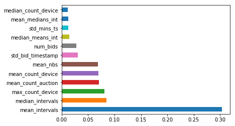

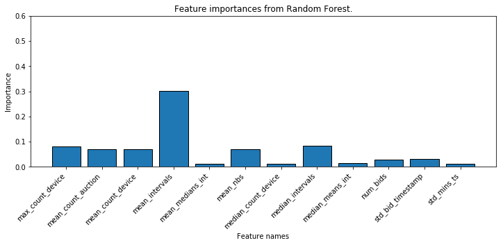

```python
def plot_feature_importances(series, model_name):
    """ Plots a bar chart of colored points from a dictionary of the form:
    {'category': {'num_bidders': 0.0, 'perc_bots(%)': 0.0},  ... } """

    # initialize figure axes and indices
    fig, ax = plt.subplots()

    # adjust the size of the figure
    fig.set_figwidth(12)
    fig.set_figheight(4)

    # set axes
    ax.set_title('Feature importances from {}.'.format(model_name))
    ax.set_xlabel('Feature names')
    ax.set_ylabel('Importance')
    ax.set_ylim([0, 0.6])
    # get the labels to rotate them
    labels = ax.get_xticklabels()
    # rotate
    plt.setp(labels, rotation=45, horizontalalignment='right')

#     # This is  the colormap I'd like to use.
#     cmap = cm.ScalarMappable(col.Normalize(0, 99), cmap=plt.get_cmap('Reds'))
    # Plot histogram.
    ax = plt.bar(series.index.values,
                 series.values, align='center')#, color=cmap.to_rgba(bot_percentages))
    # get the children
    for i, child in enumerate(ax.get_children()):
        # set the edgecolor for every bar
        child.set_edgecolor((0,0,0))

    plt.show()

# find the best features
best_features_RF = best_clf_RF.feature_importances_

#print(best_features_RF)

# find the indices of the best features
best_features_idx_RF = best_features_RF.argsort()[-12:][::-1]# should be -33

#print(best_features_idx_RF)

d_features_RF = {}

for idx in best_features_idx_RF:
    d_features_RF[X_columns[idx]] = best_features_RF[idx]

# make dict into a sorted series
d_features_RF = pd.Series(d_features_RF).sort_values(ascending=False)

print(d_features_RF.index.values)

#print(d_features_RF)
d_features_RF.plot(kind='barh')
plot_feature_importances(d_features_RF, "Random Forest")
```

#### Computing and visualizing AUROC scores

After making the random search in the desired parameter space, we will grab the best model and use it for a 10-fold cross validation to compute its final AUROC score. We will also visualize the mean score along with all other scores for each separate validation round.

As said we are using 10-fold cv here but that was not the case for parameter optimization, where we used 3-fold, its default setting. A 10-fold would make the Random Search considerably more time consuming. The only reason to make it 10-fold is to have a slightly more accurate auc rating and see a better picture of the span of accuracies aurocs can take. Of course the lower the std of AUROC scores the better its accuracy and consistency.

Also, because the dataset is heavily skewed with humans instead of bots, as we also did earlier we will select the StratifiedKFold implementation of cross-validation (from sklearn), which makes sure that it preserves an equal presense of ys' of both classes.

```python
from scipy import interp
from sklearn.model_selection import StratifiedKFold, RepeatedStratifiedKFold
from sklearn.metrics import roc_curve, auc

np.set_printoptions(threshold=400)

def make_and_plot_AUROC(clf, X, y, n_folds=10, RF=True, shuffle=True, save_name=''):
    """ Calculates the mean AUROC and plots it."""

    start = time()

    # initialize the cross validation object for 10 folds
    cv = StratifiedKFold(n_splits=n_folds, shuffle=shuffle, random_state=0)

    tprs = []
    aucs = []
    mean_fpr = np.linspace(0, 1, 100)

    feature_scores = []

    fig = plt.figure()
    ax = plt.subplot(111)

    fig.set_figwidth(8)
    fig.set_figheight(6)

    i = 0
    for train, test in cv.split(X, y):

        if RF:
            probas_ = clf.fit(X[train], y[train]).predict_proba(X[test])
        else:
            # prep the data
            data_train = xgb.DMatrix(X[train], label=y[train])
            data_test = xgb.DMatrix(X[test], label=y[test])

            # get the booster instance after training
            model = clf.train(best_params, data_train,
                              number_of_iterations["after_function_param"]+5)

            # get the predictions
            probas_ = model.predict(data_test)

            # turn the predictions into correct format
            probas_ = np.array([(1-x, x) for x in probas_])

        # Compute ROC curve and area under the curve
        fpr, tpr, thresholds = roc_curve(y[test], probas_[:, 1], pos_label=1)
        tprs.append(interp(mean_fpr, fpr, tpr))
        tprs[-1][0] = 0.0
        roc_auc = auc(fpr, tpr)
        aucs.append(roc_auc)
        ax.plot(fpr, tpr, lw=1, alpha=0.3,
                 label='ROC fold %d (AUC = %0.2f)' % (i, roc_auc))

        i += 1
    ax.plot([0, 1], [0, 1], linestyle='--', lw=2, color='r',
             label='Luck', alpha=.8)

    mean_tpr = np.mean(tprs, axis=0)
    mean_tpr[-1] = 1.0
    mean_auc = auc(mean_fpr, mean_tpr)
    std_auc = np.std(aucs)
    ax.plot(mean_fpr, mean_tpr, color='b',
             label=r'Mean ROC (AUC = %0.2f $\pm$ %0.2f)' % (mean_auc, std_auc),
             lw=2, alpha=.8)

    std_tpr = np.std(tprs, axis=0)
    tprs_upper = np.minimum(mean_tpr + std_tpr, 1)
    tprs_lower = np.maximum(mean_tpr - std_tpr, 0)
    ax.fill_between(mean_fpr, tprs_lower, tprs_upper, color='grey', alpha=.2,
                     label=r'$\pm$ 1 std. dev.')

    ax.set_xlim([-0.05, 1.05])
    ax.set_ylim([-0.05, 1.05])
    ax.set_xlabel('False Positive Rate')
    ax.set_ylabel('True Positive Rate')
    ax.set_title('AUROC curves of the {} folds and their mean curve.'.format(n_folds))
    ax.legend(loc='center left', bbox_to_anchor=(1, 0.5))
    if save_name:
        plt.savefig('images/ROC visualization of {} for {} folds.png'.format(save_name, n_folds),
                    bbox_inches='tight')
    plt.show()

    print("The full auc score is {}.".format(mean_auc))
    print("The std of the mean auc score is {}.\n".format(std_auc))

    print("The time it took for making and plotting the mean curve is {}.".format(time() - start))
```

#### Using the models to compute a final AUROC

In the next cells we will use the above function for both Random Forest and XGBooster classifiers that we trained.

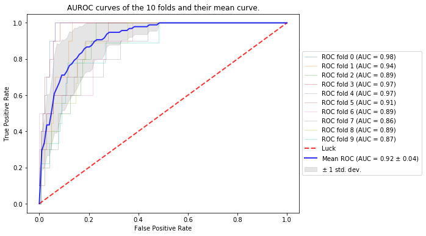

```
The full auc score is 0.9161952861952862.
The std of the mean auc score is 0.04253281467345126.

The time it took for making and plotting the mean curve is 196.95627903938293.
```

```python
# use make_and_plot_AUROC with Random Forest
make_and_plot_AUROC(best_clf_RF, X, y, RF=True, shuffle=False)
```

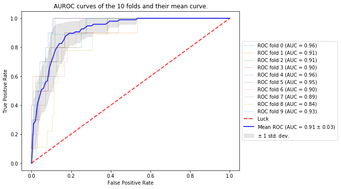

```
The full auc score is 0.9147923681257014.
The std of the mean auc score is 0.03378376035235361.

The time it took for making and plotting the mean curve is 196.80843424797058.
```

```python
# use make_and_plot_AUROC with Random Forest
make_and_plot_AUROC(best_clf_RF, X, y, RF=True, shuffle=True)
```

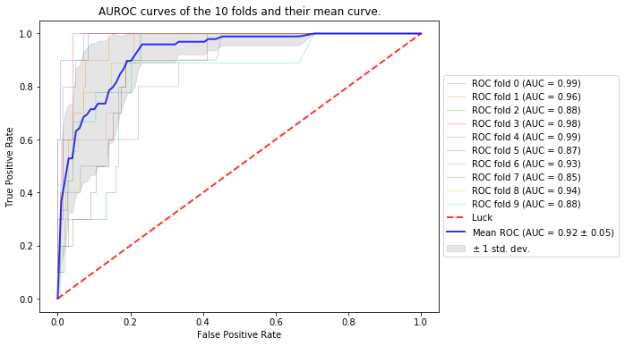

```
The full auc score is 0.9234698840254396.
The std of the mean auc score is 0.05079423957347498.

The time it took for making and plotting the mean curve is 12.001513957977295.
```

```python
# use make_and_plot_AUROC with XGB
make_and_plot_AUROC(best_clf_XGB, X, y, RF=False, shuffle=False, save_name='XGB')
```

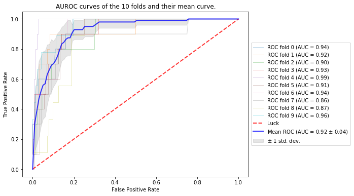

```
The full auc score is 0.9209539842873176.
The std of the mean auc score is 0.036492545698225465.

The time it took for making and plotting the mean curve is 12.291213274002075.
```

```python
# use make_and_plot_AUROC with XGB
make_and_plot_AUROC(best_clf_XGB, X, y, RF=False, shuffle=True)
```

#### Sensitivity Analysis of the XGB model

To do the sensitivity analysis we will build 5 training datasets with permutations of the initial dataset and then use the XGB model to make predictions on them to see if its robustness remains.

```
Plot for the test number 1:
```

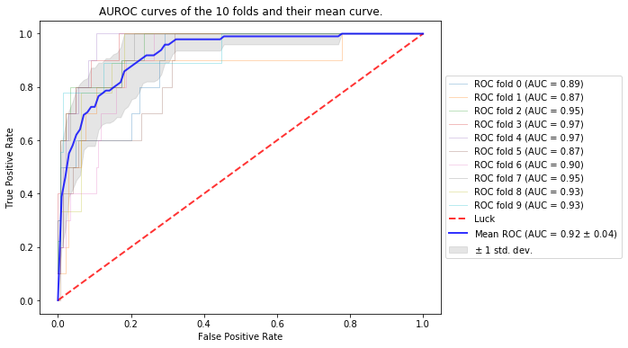

```
The full auc score is 0.9227721661054994.
The std of the mean auc score is 0.03510053864875258.

The time it took for making and plotting the mean curve is 10.558497905731201.


Plot for the test number 2:
```

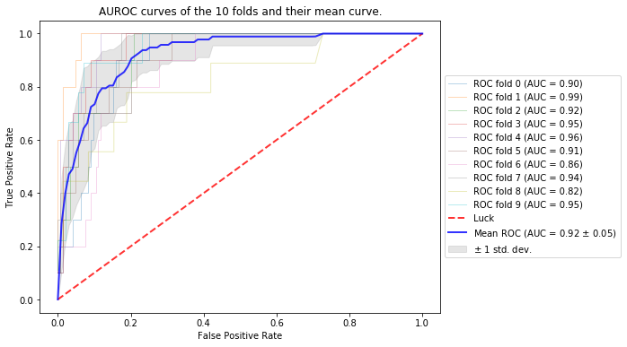

```
The full auc score is 0.9205898491083676.
The std of the mean auc score is 0.046260634843805624.

The time it took for making and plotting the mean curve is 10.292309284210205.


Plot for the test number 3:
```

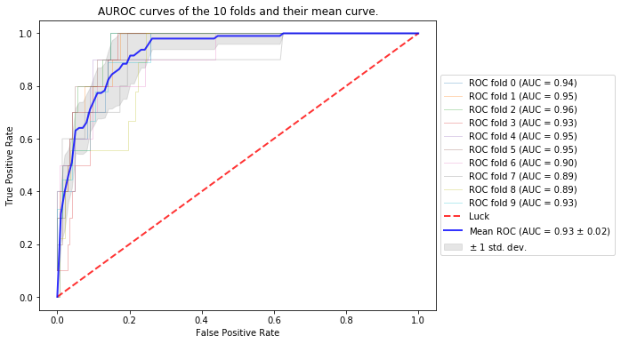

```
The full auc score is 0.9267564534231201.
The std of the mean auc score is 0.023132581665923597.

The time it took for making and plotting the mean curve is 9.456730127334595.


Plot for the test number 4:
```

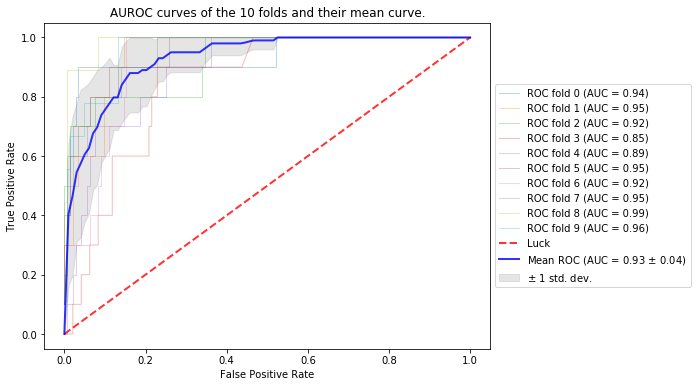

```
The full auc score is 0.929041169268442.
The std of the mean auc score is 0.037634005525322416.

The time it took for making and plotting the mean curve is 9.378655910491943.


Plot for the test number 5:
```

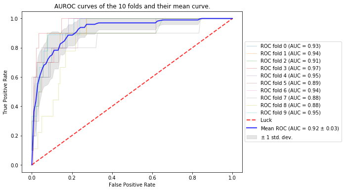

```
The full auc score is 0.9222748699112335.
The std of the mean auc score is 0.032590799524148464.

The time it took for making and plotting the mean curve is 9.574798345565796.
```

```python
# Load the bidders train dataset
XX = pd.read_csv("data/bidders_full_features.csv", index_col=0)

for i in range(1,6):

    # Shuffle the data frame to account for any possible biases when making the bids dataset
    XX_XX = XX.sample(frac=1, random_state=i)#.reset_index(drop=True)

    # Separate the outcomes to a series
    yy_yy = XX_XX.outcome

    # Drop the outcome column from the dataset
    XX_XX.drop(columns=['bidder_id', 'outcome'], inplace=True)

    # turn into nd arrays
    XX_XX = XX_XX.values
    yy_yy = yy_yy.values

    print("Plot for the test number {}:".format(i))

    # use make_and_plot_AUROC with Random Forest
    make_and_plot_AUROC(best_clf_XGB, XX_XX, yy_yy, RF=False, shuffle=False)

    print("\n")
```

#### Most Important Features

In the next few cells we will try to make a function to find out the most important features for XGB. The XGB API gives us alot of options to look for interesting features. We can look at the features according to the weights in XGB or according to the gain in the trees.

```python
np.set_printoptions(threshold=400)
pd.set_option('display.max_rows', 30)

def calc_and_plot_feature_importances(clf, X, y, column_names,
                                      n_folds=10,
                                      imp_type='weight',
                                      avg=True,
                                      num_val_zoom=10,
                                      save_name=''):
    """ Calculates the mean AUROC and plots it."""

    start = time()

    # initialize the cross validation object for 10 folds
    cv = StratifiedKFold(n_splits=n_folds, random_state=0)

    # make a list of the possible feature names by the XGB
    f_scores = ['f'+str(xx) for xx in range(X[0].shape[0])]

    # initialize them into a series as zeros
    feature_scores = {x:[] for x in f_scores}

    i = 0
    for train, test in cv.split(X, y):

        # prep the data
        data_train = xgb.DMatrix(X[train], label=y[train])
        data_test = xgb.DMatrix(X[test], label=y[test])

        # get the booster instance after training
        model = clf.train(best_params, data_train,
                          number_of_iterations["after_function_param"]+5)

        # add the importance scores to the list
        ss = model.get_score(importance_type=imp_type)

        # loop over all feature, value pairs
        for name, value in ss.items():
            # add all gain values to dictionary
            feature_scores[name].append(value)

    # loop over all feature, value pairs
    for name, value in feature_scores.items():
        if value:
            # find the average of the values and update the value
            feature_scores[name] = np.sum(value)/n_folds if avg else np.sum(value)
        else:
            # add its gain to zero
            feature_scores[name] = 0

    # get the scores into a series and sort them
    feature_scores = pd.Series(feature_scores).sort_values(ascending=False)

    feature_scores = feature_scores

    # find the corresponding names for each feature
    cols = [column_names[int(i[1:])] for i in feature_scores.index.values[:num_val_zoom]]

    # find the corresponding names for each feature
    all_cols = [column_names[int(i[1:])] for i in feature_scores.index.values]

    feature_scores_polished = pd.Series(feature_scores.values, index=all_cols)

    # init the figure and the axes object
    fig, (ax1, ax2) = plt.subplots(1, 2)
    fig.set_tight_layout(False)

    fig.set_figwidth(12)#8)
    fig.set_figheight(6)

    ind = list(range(feature_scores.shape[0]))
    ax1.bar(ind[:num_val_zoom], feature_scores.values[:num_val_zoom], align='center')
    ax2.bar(ind, feature_scores.values, width=1., align='center')

    # set the x axis ticks
    ax1.set_xticks(ind[:num_val_zoom])
    #ax2.set_xticks(ind)
    # set the labels of the x axis ticks
    ax1.set_xticklabels(cols)

    # set text axes 1
    ax1.set_title('Best {} features'.format(num_val_zoom))
    ax1.set_xlabel('Feature Names')
    ax1.set_ylabel(imp_type)
    # set text axes 2
    ax2.set_title('All Features')
    ax2.set_xlabel('Features')
    ax2.set_ylabel(imp_type)
    # get the labels to rotate them
    labels1 = ax1.get_xticklabels()
    labels2 = ax2.get_xticklabels()
    # rotate
    plt.setp(labels1, rotation=45, horizontalalignment='right')
    plt.setp(labels2, rotation=45, horizontalalignment='right')

    if save_name:
        plt.savefig('images/Feature ranking XGB{}.png'.format(save_name), bbox_inches='tight')

    plt.show()

    print("The series of 10 best scores is:\n{}.\n".format(feature_scores_polished))
    print("The time it took for making and plotting the mean curve is {}.".format(time() - start))
```

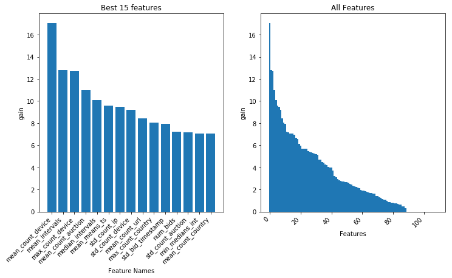

```
The series of 10 best scores is:
mean_count_device       17.055523
mean_intervals          12.850028
max_count_device        12.693311
mean_count_auction      11.001904
median_intervals        10.086488
mean_means_ts            9.562254
std_count_ip             9.449274
std_count_device         9.212419
mean_count_url           8.427992
max_count_country        8.039988
std_bid_timestamp        7.960494
num_bids                 7.234622
std_count_auction        7.165840
min_medians_int          7.069709
mean_count_country       7.043772
                          ...
min_stds_ts              0.000000
median_count_auction     0.000000
std_rsb                  0.000000
min_rsb                  0.000000
min_count_country        0.000000
median_rsb               0.000000
median_count_ip          0.000000
min_count_device         0.000000
std_nps                  0.000000
mean_nps                 0.000000
median_nps               0.000000
max_nps                  0.000000
min_count_auction        0.000000
min_nps                  0.000000
min_means_ts             0.000000
Length: 109, dtype: float64.

The time it took for making and plotting the mean curve is 10.646560907363892.
```

```python
calc_and_plot_feature_importances(best_clf_XGB, X, y, X_columns,
                                  imp_type='gain', avg=True, num_val_zoom=15,
                                  save_name=' avg gain')
```

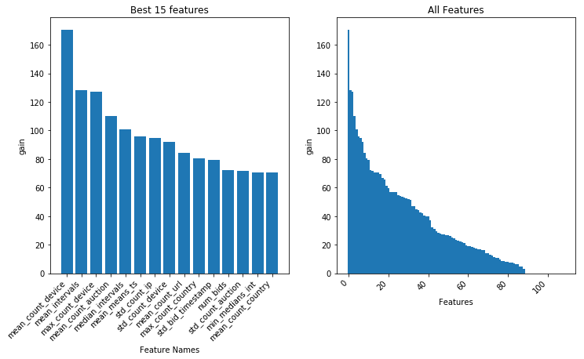

```
The series of 10 best scores is:
mean_count_device       170.555229
mean_intervals          128.500281
max_count_device        126.933113
mean_count_auction      110.019045
median_intervals        100.864877
mean_means_ts            95.622545
std_count_ip             94.492737
std_count_device         92.124194
mean_count_url           84.279922
max_count_country        80.399877
std_bid_timestamp        79.604945
num_bids                 72.346221
std_count_auction        71.658403
min_medians_int          70.697090
mean_count_country       70.437720
                           ...
min_stds_ts               0.000000
median_count_auction      0.000000
std_rsb                   0.000000
min_rsb                   0.000000
min_count_country         0.000000
median_rsb                0.000000
median_count_ip           0.000000
min_count_device          0.000000
std_nps                   0.000000
mean_nps                  0.000000
median_nps                0.000000
max_nps                   0.000000
min_count_auction         0.000000
min_nps                   0.000000
min_means_ts              0.000000
Length: 109, dtype: float64.

The time it took for making and plotting the mean curve is 10.789661407470703.
```

```python
calc_and_plot_feature_importances(best_clf_XGB, X, y, X_columns,
                                  imp_type='gain', avg=False, num_val_zoom=15,
                                  save_name=' sum gain')
```

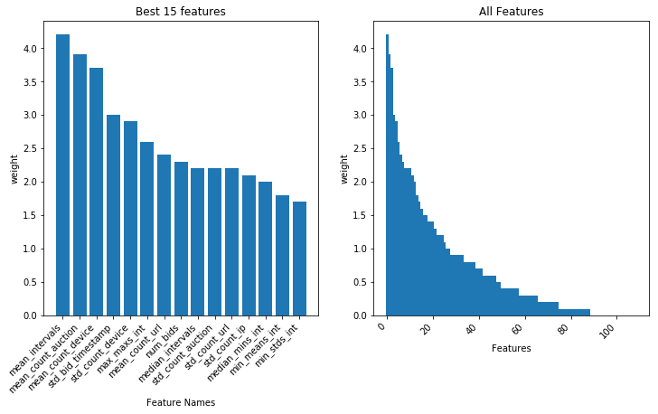

```
The series of 10 best scores is:
mean_intervals                 4.2
mean_count_auction             3.9
mean_count_device              3.7
std_bid_timestamp              3.0
std_count_device               2.9
max_maxs_int                   2.6
mean_count_url                 2.4
num_bids                       2.3
median_intervals               2.2
std_count_auction              2.2
std_count_url                  2.2
std_count_ip                   2.1
median_mins_int                2.0
min_means_int                  1.8
min_stds_int                   1.7
                              ...
min_nbs                        0.0
min_stds_ts                    0.0
min_count_country              0.0
num_periods_participated_in    0.0
min_means_ts                   0.0
max_nbs                        0.0
min_count_auction              0.0
median_count_auction           0.0
std_rsb                        0.0
median_rsb                     0.0
min_count_url                  0.0
min_rsb                        0.0
min_count_ip                   0.0
median_count_ip                0.0
min_count_device               0.0
Length: 109, dtype: float64.

The time it took for making and plotting the mean curve is 10.702845573425293.
```

```python
calc_and_plot_feature_importances(best_clf_XGB, X, y, X_columns,
                                  imp_type='weight', avg=True, num_val_zoom=15,
                                  save_name=' avg weight')
```

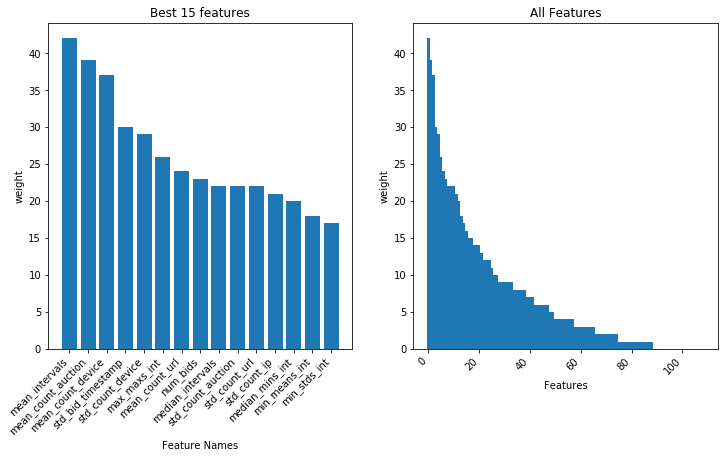

```
The series of 10 best scores is:
mean_intervals                 42
mean_count_auction             39
mean_count_device              37
std_bid_timestamp              30
std_count_device               29
max_maxs_int                   26
mean_count_url                 24
num_bids                       23
median_intervals               22
std_count_auction              22
std_count_url                  22
std_count_ip                   21
median_mins_int                20
min_means_int                  18
min_stds_int                   17
                               ..
min_nbs                         0
min_stds_ts                     0
min_count_country               0
num_periods_participated_in     0
min_means_ts                    0
max_nbs                         0
min_count_auction               0
median_count_auction            0
std_rsb                         0
median_rsb                      0
min_count_url                   0
min_rsb                         0
min_count_ip                    0
median_count_ip                 0
min_count_device                0
Length: 109, dtype: int64.

The time it took for making and plotting the mean curve is 10.86773157119751.
```

```python
calc_and_plot_feature_importances(best_clf_XGB, X, y, X_columns,
                                  imp_type='weight', avg=False, num_val_zoom=15,
                                  save_name=' sum weight')
```